# From Scores to Lending Decisions

Applicant PD scorecard · risk grades, cut-off options and operating rules

Chuch

November 2026

## The short version

34%of all defaults sit in the riskiest 11% of applicants

The scorecard sorts applicants into **five risk grades** that hold up on unseen data.

- **Decline Grade 5:** approve 89% of applicants, default rate falls from 8.6% to 6.4%
- **Refer Grade 4** to a senior assessor with tighter conditions
- **Fast-track Grades 1 and 2**, almost half of all applicants

Recommendation: decline Grade 5, refer Grade 4, and set a profit-based cut-off once loss and margin data are available.

## What the model does

**The question:** how likely is this applicant to have difficulty repaying?

- Logistic regression scorecard, **12 application-time fields** (credit scores, job tenure, loan-to-price, repayment size, occupation, education, area)
- Trained on **246,000** Home Credit loans, tested on **61,500** it never saw
- Output: an *estimated probability of payment difficulty* (PD), mapped to Grades 1 to 5

**How good is it?**

- Test **Gini 0.49** (0 = coin toss, 1 = perfect)
- Train and test Gini within 0.003: **no overfitting**
- Default rate rises in every PD decile: **ranking holds**

Gender is excluded by design (responsible lending). The target is a payment-difficulty flag, not a Basel 90+ days default.

## The grades separate risk cleanly

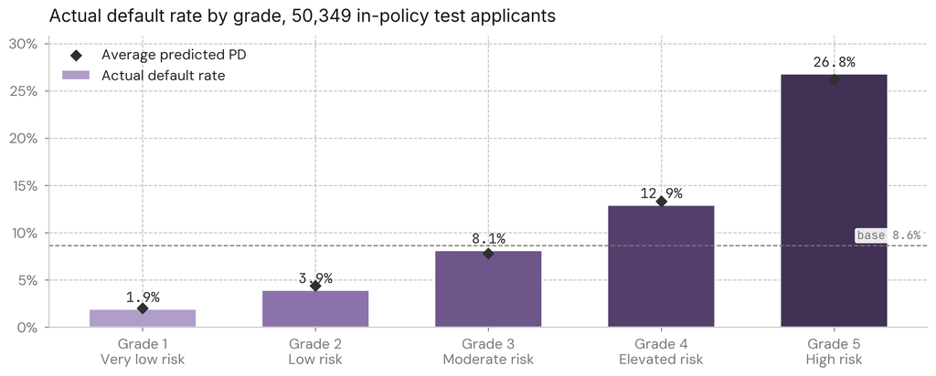

Each grade defaults more than the one before, from about 2% to about 27%, and predicted PD tracks the actual rate within 0.5 pp in every grade.

## Where the defaults sit

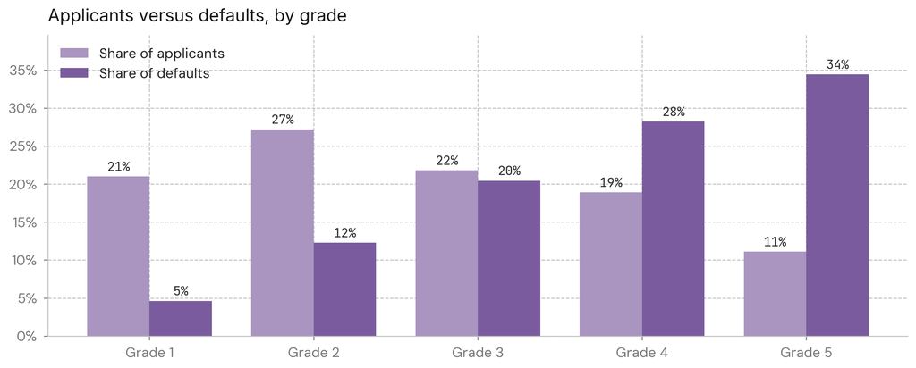

Grades 4 and 5 are 30% of applicants but 63% of defaults. That concentration is what makes a cut-off worthwhile.

## Cut-off options

| Policy | Approval rate | Defaults avoided | Default rate of approved |
| --- | --- | --- | --- |
| Approve all | 100% | 0% | 8.6% |
| Decline Grade 5 | 89% | 34% | 6.4% |
| Decline Grades 4 to 5 | 70% | 63% | 4.6% |
| Decline Grades 3 to 5 | 48% | 83% | 3.0% |
| Decline Grades 2 to 5 | 21% | 95% | 1.9% |

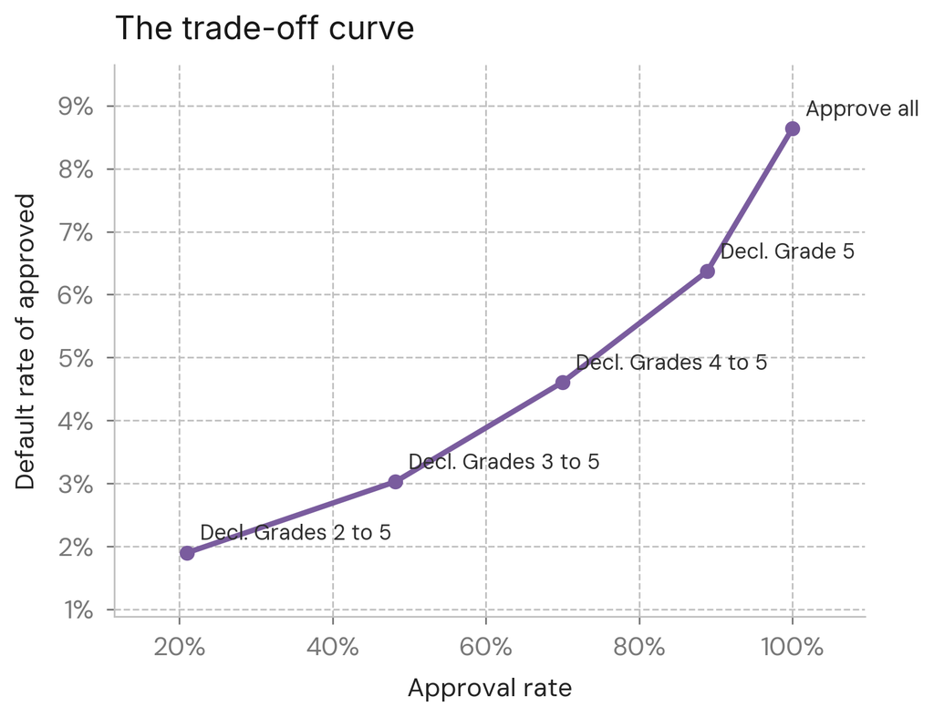

This shows the trade-off, not the optimum. Choosing the cut-off properly needs loss given default and margin by grade, which this dataset does not have.

|  | Applicant | Profile | Credit score | Loan / price | PD | Grade |
| --- | --- | --- | --- | --- | --- | --- |
| G1 | **The Steady Professional** | 52, accountants, 18 yrs in job, bachelor degree, area 1 | Good | 0.83 | 1.9% | 1 |
| G2 | **The Established Worker** | 41, core staff, 9 yrs in job, year 12, area 2 | Average | 0.91 | 7.7% | 3 (target 2) |
| G3 | **The Thin-Margin Earner** | 33, sales staff, 4 yrs in job, year 12, area 2 | Average | 0.96 | 10.5% | 4 (target 3) |
| G4 | **The Early-Career Stretch** | 25, laborers, 1.5 yrs in job, year 12, area 3 | Average | 1.00 | 14.6% | 4 |
| G5 | **The Fragile Applicant** | 23, low-skill laborers, 0.5 yrs in job, left school before year 12, area 3 | Below average | 1.04 | 52.3% | 5 |

Same loan for all five (500,000 over 36 months). Only the applicant changes, and the credit score does most of the work.

## How each grade is handled

| Grade | Example | Decision path | Approval authority | Checks | Pricing | After funding |
| --- | --- | --- | --- | --- | --- | --- |
| 1 | Steady Professional | Auto-approve, same day | Lowest level | Light | Best rate | Standard |
| 2 | Established Worker | Approve | Standard | Standard | Standard | Standard |
| 3 | Thin-Margin Earner | Approve with conditions | Standard | Full income verification | Small loading | Standard |
| 4 | Early-Career Stretch | Refer to senior assessor | Senior | Full, lower loan-to-price cap | Risk-based loading | Early contact on a missed payment |
| 5 | Fragile Applicant | Decline, or refer with deposit | Credit manager | Full | n/a | n/a |

Effort follows risk: almost half the book moves faster, and assessor time goes to the grades where defaults sit.

## Recommendations

1. **Adopt the five-grade scale** for application decisions. It ranks risk on unseen data and is simple to explain to assessors.
2. **Decline Grade 5** (or require a deposit and senior approval). This removes about a third of defaults for an 11% fall in approvals.
3. **Refer Grade 4** with a lower loan-to-price cap and risk-based pricing rather than declining it outright.
4. **Fast-track Grades 1 and 2** to cut turnaround for about half of applicants.
5. **Monitor monthly**: grade mix, actual default rate per grade, and population stability. Re-check the cut-off if Grade 5 moves away from 11% of applicants.

## Limits of this analysis

- **Approved applicants only.** The model never saw declined applicants (no reject inference), so true risk in Grades 4 and 5 may be higher.
- **Payment-difficulty target**, not a Basel default, so PDs are not regulatory PDs.
- **No loss or margin data**, so the cut-off is a trade-off, not a profit optimum.
- **Not calibrated**: grade averages line up on test, but PDs have not been formally calibrated.
- **Anonymised inputs**: credit scores, area rating and amounts are Home Credit values, translated for the dashboard.

Illustrative portfolio model on public Kaggle data. Not a production lending model.

## Next steps

- **Challenger:** LightGBM on the same 12 fields to measure how much signal the scorecard leaves on the table
- **Calibration** by grade and a population stability check
- **Monotonic binning** to remove the two known risk spikes (450,000 purchase price, 24-month term)
- **Profit-based cut-off** once loss given default and margin are available
- **Live dashboard:** every persona above can be scored in the app

Decline Grade 5, refer Grade 4, fast-track Grades 1 and 2.

A five-grade scale that ranks risk on unseen data, and a cut-off the business can *choose*.

Flagship PD Model · Home Credit data · CreditRiskLearning